# Chapter 6 Regression

Regression to model the relationship between the response and a few independent variables. Linear regression, the relationship is linear.

## 6.1 Simple Linear regression

Simple linear regression is a statistical method used to predict a continuous response variable from a single explanatory variable. For example, consider the `cars` data in R, where `speed` represents a car’s speed and `dist` represents its stopping distance.

If a car were selected at random, one simple guess for its stopping distance would be the overall mean stopping distance for all cars in the dataset. This might be a reasonable starting point if no other information were available. However, such a guess would often be inaccurate because cars traveling at different speeds are expected to have different stopping distances.

Since stopping distance is related to speed, we can improve prediction by using speed as an explanatory variable. A statistical method that takes advantage of this relationship is simple linear regression.

The term *simple* linear regression means that the model includes only one explanatory variable. In this example, `speed` is the explanatory variable, and `dist` is the response variable. The goal is to describe how stopping distance changes with speed and to use that relationship to predict stopping distance for a given speed.

The statistical model for simple linear regression is

$$ Y_i = \beta_0 + \beta_1 X_i + \varepsilon_i, \qquad i = 1,2,\dots,n, $$

where:

- $Y_i$ is the response variable for the $i$th observation,
- $X_i$ is the explanatory variable for the $i$th observation,
- $\beta_0$ is the intercept,
- $\beta_1$ is the slope,
- $\varepsilon_i$ is the random error term.

Equivalently, the model can be written in terms of the conditional mean:

$$ E(Y_i \mid X_i) = \beta_0 + \beta_1 X_i. $$

This equation means that the *average* value of the response variable is assumed to change linearly with the explanatory variable.

### Interpretation of the parameters

The intercept, $\beta_0$, is the mean value of the response variable when $X = 0$. In other words, it is the point where the regression line crosses the vertical axis. In some applications, this value has a practical interpretation; in others, it mainly serves to define the regression line.

The slope, $\beta_1$, represents the change in the *mean* response associated with a one-unit increase in the explanatory variable. If $\beta_1 > 0$, the mean response increases as $X$ increases. If $\beta_1 < 0$, the mean response decreases as $X$ increases. If $\beta_1 = 0$, then the explanatory variable does not help explain the mean response.

The error term, $\varepsilon_i$, represents the difference between the observed response and the mean response predicted by the regression line. It captures the variation in the response that is not explained by the explanatory variable alone.

### Assumptions of simple linear regression

Simple linear regression is based on the following assumptions:

1. **Linearity**
   The mean of the response variable is a linear function of the explanatory variable: $$ E(Y_i \mid X_i) = \beta_0 + \beta_1 X_i. $$
2. **Independence** (how the data were collected)

   The observations are independent of one another. Equivalently, the error terms are assumed to be independent.
3. **Constant variance**
   The error terms have the same variance for all values of the explanatory variable: $$ \operatorname{Var}(\varepsilon_i) = \sigma^2. $$ This assumption is also called *homoscedasticity*.
4. **Normality of errors**
   The error terms are normally distributed: $$ \varepsilon_i \sim N(0,\sigma^2). $$ This assumption is mainly needed for statistical inference, such as confidence intervals and hypothesis tests.

For example, consider the `cars` data in R, where `speed` represents a car’s speed and `dist` represents its stopping distance. The regression model is $$ dist_i = \beta_0 + \beta_1 speed + e_i. $$

Please describe the meanings of paramters for this particula model.

$\beta_0$ : the average stopping distance when the speed is zero.

$\beta_1$ : the change in the mean stopping distance when the speed increase by 1 unit.

## Estimation of parameters and prediction

In a simple linear regression model, the unknown parameters $\beta_0$ and $\beta_1$ are typically estimated by the **least-squares method**. The resulting estimates are denoted by $\hat{\beta}_0$ and $\hat{\beta}_1$, and they are called the **least-squares estimators**. The basic idea is intuitive: among all possible straight lines that could be drawn through the data, we choose the one that fits the observed points best.

To explain what “best” means, consider the difference between an observed response value and the value predicted by a fitted line. This difference is called a **residual**. Some residuals are positive and some are negative, so simply adding them would allow positive and negative values to cancel out. To avoid this, the least-squares method squares the residuals and then adds them together. The line chosen is the one that makes this total squared error as small as possible. In this sense, the least-squares estimators produce the fitted line that stays as close as possible to the observed data overall.

The least-squares estimators are

$$ \hat{\beta}_1 = \frac{\sum_{i=1}^n (X_i-\bar{X})(Y_i-\bar{Y})} {\sum_{i=1}^n (X_i-\bar{X})^2}, \qquad \hat{\beta}_0 = \bar{Y} - \hat{\beta}_1 \bar{X}. $$

**(1)**

Using these estimates, the fitted regression line is

$$ \hat{Y}_i = \hat{\beta}_0 + \hat{\beta}_1 X_i. $$

The least-squares estimators are chosen to minimize the sum of squared residuals,

$$ SSE = \sum_{i=1}^n (Y_i-\hat{Y}_i)^2. $$

Once the regression parameters have been estimated, the fitted line can be used for prediction. If the explanatory variable takes the value $x$, then the predicted mean response is

$$ \hat{Y}(x) = \hat{\beta}_0 + \hat{\beta}_1 x. $$

**(2)**

This is the estimated value of $E(Y \mid X=x)$, so $\hat{Y}(x)$ represents the estimated **average** response for all observations having explanatory variable value $x$.

## Residual variance

The residual for the $i$th observation is

$$ e_i = Y_i - \hat{Y}_i. $$

The residual sum of squares is

$$ SSE = \sum_{i=1}^n e_i^2. $$

An unbiased estimator of the error variance $\sigma^2$ is

$$ s^2 = \frac{SSE}{n-2}, $$

and the corresponding residual standard error is

$$ s = \sqrt{\frac{SSE}{n-2}}. $$

This quantity measures the typical size of the residuals and describes how far the observed responses tend to fall from the fitted regression line.

## Confidence interval for the mean response at $x$

A confidence interval at $x$ is used when the goal is to estimate the **mean response** $E(Y \mid X=x)$. In other words, it gives a plausible range for the average value of the response variable when the explanatory variable equals $x$.

The standard error of $\hat{Y}(x)$ is

$$ SE\big(\hat{Y}(x)\big) = s \sqrt{ \frac{1}{n} + \frac{(x-\bar{X})^2}{\sum_{i=1}^n (X_i-\bar{X})^2} }. $$

Therefore, a $100(1-\alpha)\%$ confidence interval for the mean response at $x$ is

$$ \hat{Y}(x) \pm t_{\alpha/2,\;n-2} \, s \sqrt{ \frac{1}{n} + \frac{(x-\bar{X})^2}{\sum_{i=1}^n (X_i-\bar{X})^2} }. $$

**(3)**

This interval reflects the uncertainty in estimating the regression line and, therefore, the uncertainty in estimating the mean response at the given value $x$.

## Prediction interval for a new response at $x$

A prediction interval at $x$ is used when the goal is to predict a **single future observation** rather than the mean response. Since an individual observation can vary around the regression line, a prediction interval must account for both the uncertainty in estimating the mean response and the additional random variation of individual outcomes.

The standard error for prediction is

$$ SE_{\text{pred}} = s \sqrt{ 1 + \frac{1}{n} + \frac{(x-\bar{X})^2}{\sum_{i=1}^n (X_i-\bar{X})^2} }. $$

Thus, a $100(1-\alpha)\%$ prediction interval for a new response at $x$ is

$$ \hat{Y}(x) \pm t_{\alpha/2,\;n-2} \, s \sqrt{ 1 + \frac{1}{n} + \frac{(x-\bar{X})^2}{\sum_{i=1}^n (X_i-\bar{X})^2} }. $$

**(4)**

Because it includes the extra variability of an individual future response, a prediction interval is always wider than the corresponding confidence interval at the same value of $x$.

## Meaning of the intervals

A **confidence interval** at $x$ describes a plausible range for the unknown mean response $E(Y \mid X=x)$. A **prediction interval** at $x$ describes a plausible range for a single future response value when $X=x$.

Thus, Equation **(2)** is the point estimate of the mean response, Equation **(3)** gives the confidence interval for the mean response, and Equation **(4)** gives the prediction interval for a new observation.

## Correlation and coefficient of determination

Two important measures in simple linear regression are the **correlation coefficient** and the **coefficient of determination**. Both describe the relationship between the explanatory variable $X$ and the response variable $Y$, but they focus on different aspects of that relationship.

The **sample correlation coefficient**, denoted by $r$, measures the strength and direction of the linear relationship between two quantitative variables. Its value always lies between $-1$ and $1$. If $r>0$, then larger values of $X$ tend to be associated with larger values of $Y$. If $r<0$, then larger values of $X$ tend to be associated with smaller values of $Y$. If $r$ is close to $0$, then there is little or no linear relationship between the two variables. In general, values of $r$ close to $1$ or $-1$ indicate a strong linear relationship, while values close to $0$ indicate a weak linear relationship.

In simple linear regression, the sign of the slope estimator $\hat{\beta}_1$ is the same as the sign of the correlation coefficient $r$. Thus, if the slope is positive, the correlation is positive; if the slope is negative, the correlation is negative. However, correlation measures only linear association and does not imply causation.

The **coefficient of determination**, denoted by $R^2$, measures how well the regression model explains the variability in the response variable. It is defined by

$$ R^2=\frac{SSR}{SST}=1-\frac{SSE}{SST}, $$

where $SST$ is the total sum of squares, $SSR$ is the regression sum of squares, and $SSE$ is the error sum of squares. The value of $R^2$ always lies between $0$ and $1$. A value of $R^2$ close to $1$ means that the regression model explains a large proportion of the variation in the response variable, while a value close to $0$ means that the model explains little of that variation.

For example, if $R^2=0.80$, then about $80\%$ of the variability in $Y$ is explained by its linear relationship with $X$, and the remaining $20\%$ is due to other factors and random variation. Thus, $R^2$ tells us how useful the fitted regression line is for explaining the observed variation in the response.

In simple linear regression with one explanatory variable, the coefficient of determination is the square of the sample correlation coefficient:

$$ R^2=r^2. $$

This relationship shows that the two measures are closely connected. The correlation coefficient $r$ describes both the **strength** and the **direction** of the linear relationship, whereas $R^2$ describes the **proportion of variation in the response explained by the model**. Because $R^2$ is a squared quantity, it does not indicate direction. For instance, both $r=0.9$ and $r=-0.9$ give $R^2=0.81$.

## Hypothesis testing for the slope and intercept

In simple linear regression, we often want to test whether the slope $\beta_1$ or the intercept $\beta_0$ differs from a specified value. More generally, we may test whether a parameter is equal to, greater than, or less than some constant.

For the slope, suppose we want to test

$$ H_0:\beta_1=\beta_{1,0} \qquad \text{versus} \qquad H_a:\beta_1\ne \beta_{1,0}, $$

or one of the one-sided alternatives

$$ H_a:\beta_1>\beta_{1,0} \qquad \text{or} \qquad H_a:\beta_1<\beta_{1,0}. $$

The test statistic is

$$ t=\frac{\hat{\beta}_1-\beta_{1,0}}{SE(\hat{\beta}_1)}, $$

where

$$ SE(\hat{\beta}_1)= \frac{s}{\sqrt{\sum_{i=1}^n (X_i-\bar{X})^2}}, $$

and $s^2=SSE/(n-2)$. Under the null hypothesis, this test statistic follows a $t$ distribution with $n-2$ degrees of freedom.

The same idea applies to the intercept. To test

$$ H_0:\beta_0=\beta_{0,0} \qquad \text{versus} \qquad H_a:\beta_0\ne \beta_{0,0}, $$

or one-sided alternatives, we use the test statistic

$$ t=\frac{\hat{\beta}_0-\beta_{0,0}}{SE(\hat{\beta}_0)}, $$

where

$$ SE(\hat{\beta}_0)= s\sqrt{ \frac{1}{n} + \frac{\bar{X}^2}{\sum_{i=1}^n (X_i-\bar{X})^2} }. $$

Again, under the null hypothesis, this statistic has a $t$ distribution with $n-2$ degrees of freedom.

A common special case is testing whether the slope is zero:

$$ H_0:\beta_1=0 \qquad \text{versus} \qquad H_a:\beta_1\ne 0. $$

This test examines whether the explanatory variable contributes to explaining the response. If $H_0$ is rejected, then there is evidence that the response and explanatory variable have a linear relationship. The interpretation depends on whether $X=0$ is meaningful in the problem. In many applications, the slope is of greater practical interest than the intercept.

## Example: Predicting first-year GPA from entrance test score

In this example,

- **Score** = entrance test score before the first year of study
- **GPA** = GPA during the first year of study

| Student | Score | GPA |
| --- | --- | --- |
| 1 | 81 | 3.48 |
| 2 | 83 | 3.30 |
| 3 | 97 | 4.00 |
| 4 | 86 | 3.83 |
| 6 | 99 | 4.00 |
| 8 | 75 | 3.08 |
| 9 | 80 | 3.18 |
| 11 | 95 | 3.62 |
| 12 | 88 | 3.52 |
| 13 | 88 | 3.15 |
| 15 | 81 | 3.75 |
| 18 | 69 | 2.71 |
| 19 | 91 | 3.98 |
| 21 | 76 | 3.23 |
| 22 | 83 | 3.39 |
| 24 | 79 | 3.73 |
| 26 | 72 | 3.52 |
| 27 | 92 | 3.20 |
| 28 | 86 | 3.72 |
| 30 | 95 | 3.94 |

We want to run a simple linear regression analysis to predict **GPA** using **Score**.

Here, the **dependent variable** (response variable) is **GPA**, and the **independent variable** (explanatory variable) is **Score**.

The simple linear regression model:

$$ GPA_i = \beta_0 + \beta_1 Score_i + e_i $$

where $\beta_0$ is the average GPA when the score of entrance test is zero, $\beta_1$ is the change in mean GPA when test score increase by 1.

```r
#My own simulated data
GPA.dat <- data.frame(
  Student = c(1, 2, 3, 4, 6, 8, 9, 11, 12, 13,
              15, 18, 19, 21, 22, 24, 26, 27, 28, 30),
  Score = c(81, 83, 97, 86, 99, 75, 80, 95, 88, 88,
            81, 69, 91, 76, 83, 79, 72, 92, 86, 95),
  GPA = c(3.48, 3.30, 4.00, 3.83, 4.00, 3.08, 3.18, 3.62, 3.52, 3.15,
          3.75, 2.71, 3.98, 3.23, 3.39, 3.73, 3.52, 3.20, 3.72, 3.94)
)

GPA.dat
```

A data.frame: 20 × 3

| Student <dbl> | Score <dbl> | GPA <dbl> |
| --- | --- | --- |
| 1 | 81 | 3.48 |
| 2 | 83 | 3.30 |
| 3 | 97 | 4.00 |
| 4 | 86 | 3.83 |
| 6 | 99 | 4.00 |
| 8 | 75 | 3.08 |
| 9 | 80 | 3.18 |
| 11 | 95 | 3.62 |
| 12 | 88 | 3.52 |
| 13 | 88 | 3.15 |
| 15 | 81 | 3.75 |
| 18 | 69 | 2.71 |
| 19 | 91 | 3.98 |
| 21 | 76 | 3.23 |
| 22 | 83 | 3.39 |
| 24 | 79 | 3.73 |
| 26 | 72 | 3.52 |
| 27 | 92 | 3.20 |
| 28 | 86 | 3.72 |
| 30 | 95 | 3.94 |

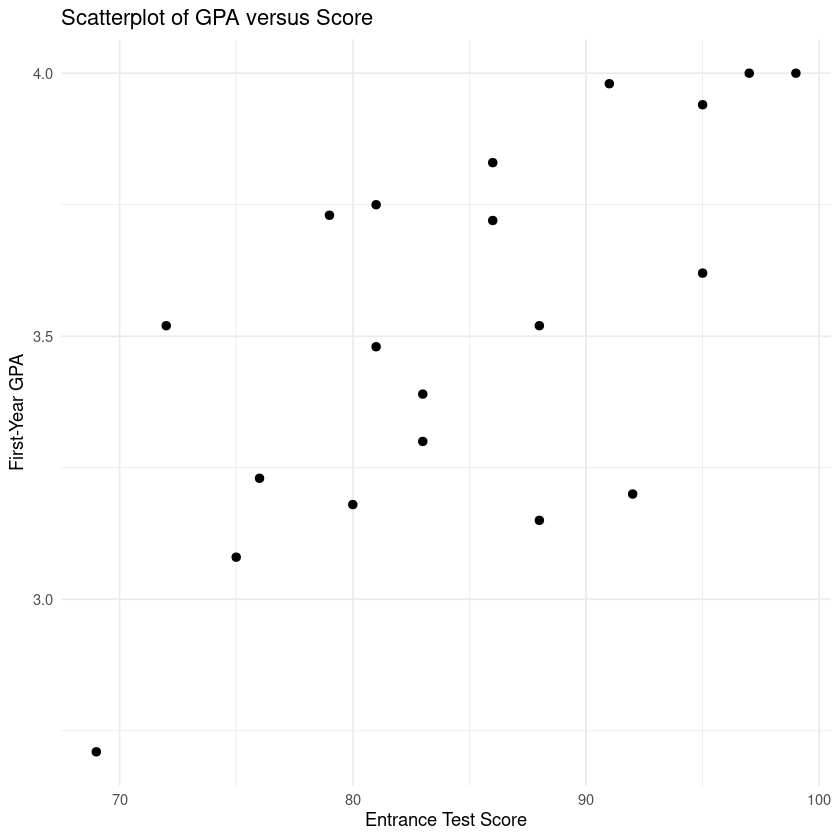

```r
library(ggplot2)

# Scatter plot
ggplot(GPA.dat, aes(x = Score, y = GPA)) +
  geom_point(size = 2) +
  labs(
    title = "Scatterplot of GPA versus Score",
    x = "Entrance Test Score",
    y = "First-Year GPA"
  ) +
  theme_minimal()
```

There is a linear relationship between entrance test score and the first year GPA. We can run a simple linear regression to see how the the first year GPA depends on the entrance test score.

According to the output, the fitted model:

$ \hat {GPA}_i = 1.136 + 0.028 Score_i $

```
Call:
lm(formula = GPA ~ Score, data = GPA.dat)

Residuals:
     Min       1Q   Median       3Q      Max
-0.51865 -0.17019  0.01538  0.19731  0.37634

Coefficients:
            Estimate Std. Error t value Pr(>|t|)
(Intercept) 1.135673   0.642261   1.768  0.09397 .
Score       0.028076   0.007539   3.724  0.00155 **
---
Signif. codes:  0 ‘***’ 0.001 ‘**’ 0.01 ‘*’ 0.05 ‘.’ 0.1 ‘ ’ 1

Residual standard error: 0.2771 on 18 degrees of freedom
Multiple R-squared:  0.4352,	Adjusted R-squared:  0.4038
F-statistic: 13.87 on 1 and 18 DF,  p-value: 0.001552
```

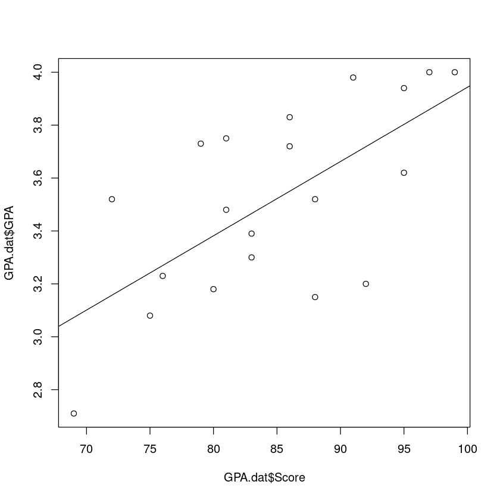

```
	Shapiro-Wilk normality test

data:  Resid
W = 0.95206, p-value = 0.3994
```

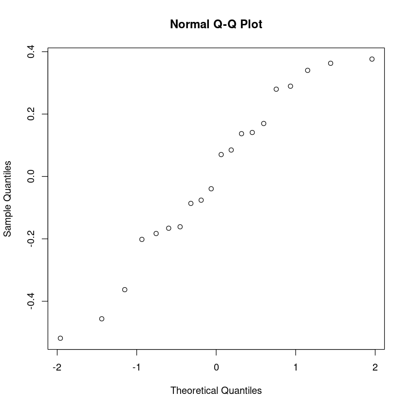

```r
#Run a simple linear regression

fit = lm(  GPA ~ Score , data = GPA.dat)
summary(fit)

plot( GPA.dat$Score, GPA.dat$GPA)
abline(fit)



#Normality
Resid = fit$residuals
qqnorm(Resid)
#QQ normal plot indicates that the data are from a normal distribuiton approximately.
#Shapiro-Wilk normality test
shapiro.test(Resid)
#p-value = 0.3994, fail to reject H0 (normality of the data). The normality assumption is ok.

#Residual plot: residuals plot against the predicted values or the independent variable.
```

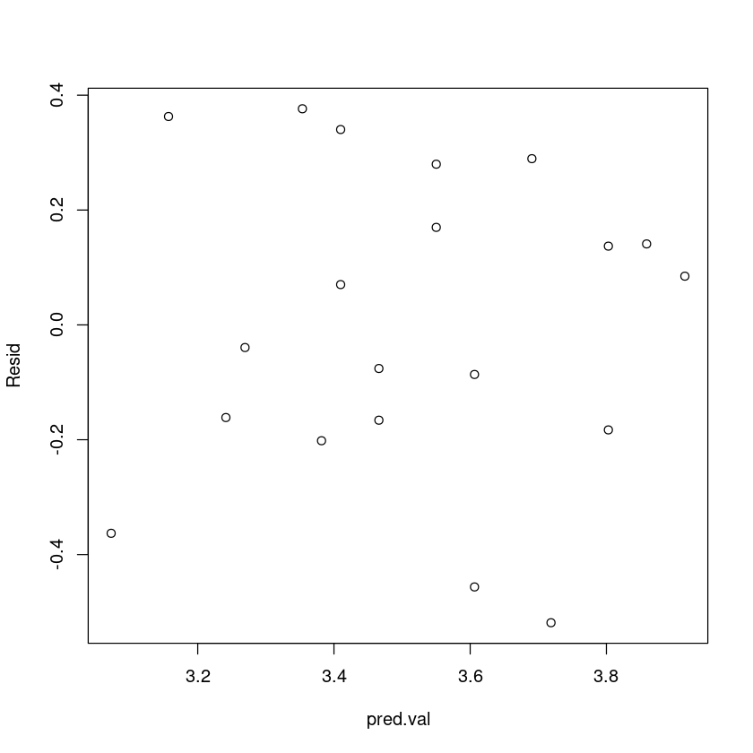

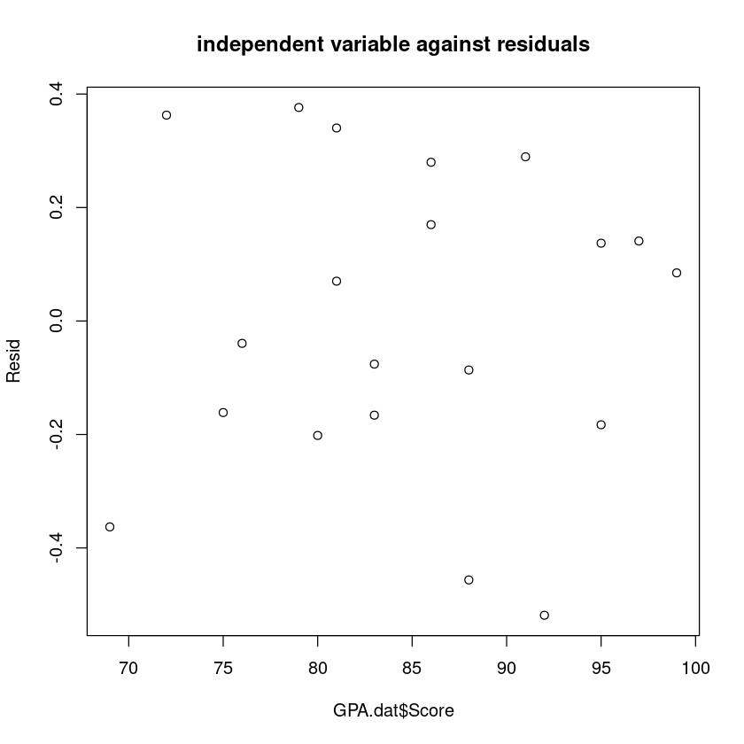

```r
#The predicted values for each observation
pred.val = fit$fitted.values

#Residual plot : residuals again the predected values
plot(pred.val, Resid)

#Residual plot: residuals vs the independent variable
plot(GPA.dat$Score, Resid, main="independent variable against residuals")
#To look at the residual plots,  if the errors are randomly spread out around the horizontal line when y=0.  No curved patterns.
#The spread out keeps constant accorss different values of the independent variable
```

a. Test if the score is useful or not to predict GPA.

H0: $\beta_1 = 0$ vs $\beta_1 \ne 0$

Two sided test

Test statistic = t = 3.724 p-value = 0.00155

Reject H0. There is sufficient evidence that score is useful to predict GPA.

b. Test if the score and GPA are positive related. ( Test if the expected GPA increases when the score increases. )

H0: $\beta_1 = 0$ vs $\beta_1 > 0$

One sided test : t = 3.724 (the same) ==> p-value = 0.00155/2 = 0.00078

If test statistic > 0 when H1 is ">" : p-value = the output p-value/2 If test statistic < 0 when H1 is ">" : p-value = 1 - (the output p-value/2)

If H1 ">": p-value = P( t distribution > test statistic)

If H1 "<": p-value = P( t distribution < test statistic)

If H1 "$\ne$": p-value = 2*P( t distribution < the absoluate value of the test statistic)

c. Test if the expected GPA increases at least 0.01 if the test score increases by 1.

H0: $\beta_1 = 0.01$ vs H1: $\beta_1 > 0.01$

The test statistic is

$$ t=\frac{\hat{\beta}_1-\beta_{1,0}}{SE(\hat{\beta}_1)} = \frac { 0.028076- 0.01}{0.007539} = 2.397665 $$

Test statistic t = 2.398

d.f = 18

Since H1 ">":

p-value = P( t distribution > test statistic) = 1 - P(t distribution with d.f. = 18 < test statistic) = 0.0137698

1 - pt(2.398, 18)

```r
(0.028076 - 0.01)/0.007539

  1 -  pt(2.398, 18)

#lm(formula = GPA ~ Score, data = GPA.dat)
GPA.dat$GPA2= GPA.dat$GPA - 0.01*GPA.dat$Score

fit1 = lm( GPA2 ~ Score , data= GPA.dat )

summary(fit1)

#P-value = 0.0276 /2   == > 0.0138 (The same)
```

2.39766547287439

0.0137698356396424

```
Call:
lm(formula = GPA2 ~ Score, data = GPA.dat)

Residuals:
     Min       1Q   Median       3Q      Max
-0.51865 -0.17019  0.01538  0.19731  0.37634

Coefficients:
            Estimate Std. Error t value Pr(>|t|)
(Intercept) 1.135673   0.642261   1.768   0.0940 .
Score       0.018076   0.007539   2.398   0.0276 *
---
Signif. codes:  0 ‘***’ 0.001 ‘**’ 0.01 ‘*’ 0.05 ‘.’ 0.1 ‘ ’ 1

Residual standard error: 0.2771 on 18 degrees of freedom
Multiple R-squared:  0.2421,	Adjusted R-squared:    0.2
F-statistic: 5.749 on 1 and 18 DF,  p-value: 0.02755
```

### Confidence intervals for the mean response when x is given

### Prediction intervals for the response when x is given

a). If the score is 80, find is the expected GPA?

$ \hat {GPA} = 1.136 + 0.028 \times 80 $

```r
#Predict function
# New observation
ndat <- data.frame(Score = 80)
predict(fit, newdata = ndat)
```

**1:** 3.38173623445826

```r
#Predict function
# New observation
#ndat <- data.frame(Score = 80)
#predict(fit, newdata = ndat)

# confidence interval for mean response
predict(fit, newdata = ndat, interval = "confidence", conf.level=0.99)

# Point prediction and prediction interval for a new observation
predict(fit, newdata = ndat, interval = "prediction", conf.level=0.9)
```

A matrix: 1 × 3 of type dbl

|  | fit | lwr | upr |
| --- | --- | --- | --- |
| 1 | 3.381736 | 3.230986 | 3.532487 |

A matrix: 1 × 3 of type dbl

|  | fit | lwr | upr |
| --- | --- | --- | --- |
| 1 | 3.381736 | 2.780358 | 3.983114 |

In class problem: use the "cars" data in R. Please run a simple linear regression to model how 'dist' depends on 'speed'. Please check the assumptions using graphical tools.

1. Is there a clear linear pattern, so that the data is suitable for a simple linear regression?
2. Run a simple linear regression, what is the fitted model?
3. Construct a QQ normal plot, and residual plots to see if the assumptions are satisfied or not.
4. Test if the speed is useful in the model.
5. Test if the expected stopping distance increase by 2 if the speed increase by 1.

Hint: dat = cars dat$dist2= cars$dist - 2*dat$speed

```r
data(cars)
#head(cars)
fit = lm(dist ~ speed, data = cars)
summary(fit)
```

```
Call:
lm(formula = dist ~ speed, data = cars)

Residuals:
    Min      1Q  Median      3Q     Max
-29.069  -9.525  -2.272   9.215  43.201

Coefficients:
            Estimate Std. Error t value Pr(>|t|)
(Intercept) -17.5791     6.7584  -2.601   0.0123 *
speed         3.9324     0.4155   9.464 1.49e-12 ***
---
Signif. codes:  0 ‘***’ 0.001 ‘**’ 0.01 ‘*’ 0.05 ‘.’ 0.1 ‘ ’ 1

Residual standard error: 15.38 on 48 degrees of freedom
Multiple R-squared:  0.6511,	Adjusted R-squared:  0.6438
F-statistic: 89.57 on 1 and 48 DF,  p-value: 1.49e-12
```

## Model checking

After fitting a simple linear regression model, it is important to check whether the model assumptions are reasonable. Model checking helps us determine whether the fitted regression line provides an appropriate description of the relationship between the explanatory variable and the response variable. If the assumptions are not satisfied, then the estimates, tests, confidence intervals, and predictions from the model may not be reliable.

A useful first step is to examine a **scatterplot** of the response variable versus the explanatory variable before fitting the model. The scatterplot helps us assess whether the relationship appears approximately linear. If the points follow a roughly straight-line pattern, then a simple linear regression model may be appropriate. On the other hand, if the pattern is curved or highly irregular, then a linear model may not fit the data well. After fitting the model, it is also helpful to add the fitted regression line to the scatterplot to see whether the line captures the overall trend in the data.

Another important step is to examine the **residuals**, which are the differences between the observed values and the fitted values. A plot of residuals versus the fitted values, or residuals versus the explanatory variable, can be used to check whether the variance appears roughly constant and whether there are signs of nonlinearity. Ideally, the residuals should be randomly scattered around zero with no clear pattern. If the spread of the residuals increases or decreases as the fitted values increase, then the constant variance assumption may be violated. If a curved pattern appears, then the linearity assumption may not hold.

The **normality assumption** is commonly checked by using a histogram of residuals, a normal Q-Q plot, or a formal normality test such as the **Shapiro-Wilk test**. If the residuals are approximately normal, then the points in the Q-Q plot should lie close to a straight line. The Shapiro-Wilk test can also be used to test the null hypothesis that the residuals come from a normal distribution. A large p-value suggests that the normality assumption is reasonable, while a very small p-value suggests departure from normality. However, the normality test should be interpreted together with the plots, since formal tests can be sensitive to sample size.

It is also important to check for **unusual observations**, such as outliers or influential points. An outlier is an observation with an unusually large residual, while an influential observation is one that has a strong effect on the fitted regression line. Such points can sometimes distort the estimated relationship and affect the regression results. Diagnostic plots and influence measures can help identify these observations for further investigation.

In addition, if the data are collected over time or in sequence, the **independence** of the errors should be considered. For time-ordered data, residuals may be correlated with one another, which violates a basic regression assumption. In such cases, plotting the residuals in their data collection order may help reveal patterns or dependence. If strong dependence is present, a different modeling approach may be needed.

Overall, model checking is an essential part of regression analysis. A fitted model should not be accepted only because the regression equation has been obtained. Instead, graphical and numerical diagnostics should be used to verify that the assumptions of linearity, constant variance, normality, and independence are reasonably satisfied.

## Multiple Regression

The multiple regression model relates one response variable to several predictors. It is commonly written as

$$ Y_i=\beta_0+\beta_1 x_{i1}+\beta_2 x_{i2}+\cdots+\beta_p x_{ip}+\varepsilon_i, \qquad i=1,2,\dots,n. $$

Here:

- $Y_i$ is the response for observation $i$,
- $x_{i1},x_{i2},\dots,x_{ip}$ are the predictor values for observation $i$,
- $\beta_0$ is the intercept,
- $\beta_1,\beta_2,\dots,\beta_p$ are regression coefficients,
- $\varepsilon_i$ is the random error term.

The model says that the mean of $Y_i$, given the predictors, is

$$ E(Y_i \mid x_{i1},x_{i2},\dots,x_{ip}) =\beta_0+\beta_1 x_{i1}+\beta_2 x_{i2}+\cdots+\beta_p x_{ip}. $$

So the fitted regression equation is

$$ \hat{Y}_i=\hat{\beta}_0+\hat{\beta}_1 x_{i1}+\hat{\beta}_2 x_{i2}+\cdots+\hat{\beta}_p x_{ip}, $$

where $\hat{\beta}_0,\hat{\beta}_1,\dots,\hat{\beta}_p$ are estimates from the data.

Under the usual assumptions,

$$ \varepsilon_i \sim \text{independent } N(0,\sigma^2), $$

or more generally,

$$ E(\varepsilon_i)=0, \qquad \operatorname{Var}(\varepsilon_i)=\sigma^2. $$

Similiar assumptions for a simple linear regression are also needed for multiple regression.

Example: Use bodyfat data at http://jse.amstat.org/datasets/fat.dat.txt and http://jse.amstat.org/datasets/fat.txt.

The bodyfat data set contains observations on 252 men, including body fat percentages estimated from underwater weighing and a set of body measurements such as age, weight, height, and body circumferences. The response variables are brozek and siri, two formulas for estimating percent body fat from body density, while the remaining variables are potential predictors. The data were discussed in Johnson (1996), based on earlier work by Penrose, Nelson, and Fisher (1985), and are widely used for regression examples. A few recording errors are known to exist in the data, including some incorrect density values and at least one implausible height measurement.

Use BodyFat (percentage of body fat) as the response variable.

Do not include Density as a predictor, because body fat percentage is calculated from body density, so it carries essentially the same information and would make the model inappropriate. If your dataset contains both Siri and Brozek body fat measures, choose only one of them as the response and do not use the other as a predictor.

| Variable | Description |
| --- | --- |
| **case** | Case number |
| **brozek** | Percent body fat using Brozek’s equation, (457/\text{density} - 414.2) |
| **siri** | Percent body fat using Siri’s equation, (495/\text{density} - 450) |
| **density** | Body density determined from underwater weighing ((\text{gm}/\text{cm}^3)) |
| **age** | Age in years |
| **weight** | Weight in pounds |
| **height** | Height in inches |
| **neck** | Neck circumference in centimeters |
| **chest** | Chest circumference in centimeters |
| **abdomen** | Abdomen circumference in centimeters |
| **hip** | Hip circumference in centimeters |
| **thigh** | Thigh circumference in centimeters |
| **knee** | Knee circumference in centimeters |
| **ankle** | Ankle circumference in centimeters |
| **biceps** | Extended biceps circumference in centimeters |
| **forearm** | Forearm circumference in centimeters |
| **wrist** | Wrist circumference in centimeters |

```r
library(mfp)
#bodyfat: percentage of body fat determined by underwater weighing
data(bodyfat)

head(bodyfat)
```

A data.frame: 6 × 17

|  | case <int> | brozek <dbl> | siri <dbl> | density <dbl> | age <int> | weight <dbl> | height <dbl> | neck <dbl> | chest <dbl> | abdomen <dbl> | hip <dbl> | thigh <dbl> | knee <dbl> | ankle <dbl> | biceps <dbl> | forearm <dbl> | wrist <dbl> |
| --- | --- | --- | --- | --- | --- | --- | --- | --- | --- | --- | --- | --- | --- | --- | --- | --- | --- |
| 1 | 1 | 12.6 | 12.3 | 1.0708 | 23 | 154.25 | 67.75 | 36.2 | 93.1 | 85.2 | 94.5 | 59.0 | 37.3 | 21.9 | 32.0 | 27.4 | 17.1 |
| 2 | 2 | 6.9 | 6.1 | 1.0853 | 22 | 173.25 | 72.25 | 38.5 | 93.6 | 83.0 | 98.7 | 58.7 | 37.3 | 23.4 | 30.5 | 28.9 | 18.2 |
| 3 | 3 | 24.6 | 25.3 | 1.0414 | 22 | 154.00 | 66.25 | 34.0 | 95.8 | 87.9 | 99.2 | 59.6 | 38.9 | 24.0 | 28.8 | 25.2 | 16.6 |
| 4 | 4 | 10.9 | 10.4 | 1.0751 | 26 | 184.75 | 72.25 | 37.4 | 101.8 | 86.4 | 101.2 | 60.1 | 37.3 | 22.8 | 32.4 | 29.4 | 18.2 |
| 5 | 5 | 27.8 | 28.7 | 1.0340 | 24 | 184.25 | 71.25 | 34.4 | 97.3 | 100.0 | 101.9 | 63.2 | 42.2 | 24.0 | 32.2 | 27.7 | 17.7 |
| 6 | 6 | 20.6 | 20.9 | 1.0502 | 24 | 210.25 | 74.75 | 39.0 | 104.5 | 94.4 | 107.8 | 66.0 | 42.0 | 25.6 | 35.7 | 30.6 | 18.8 |

```r
#Multiple regression using all independent variables

dat = bodyfat[,-c(1, 3,4)]
head(dat)
```

A data.frame: 6 × 14

|  | brozek <dbl> | age <int> | weight <dbl> | height <dbl> | neck <dbl> | chest <dbl> | abdomen <dbl> | hip <dbl> | thigh <dbl> | knee <dbl> | ankle <dbl> | biceps <dbl> | forearm <dbl> | wrist <dbl> |
| --- | --- | --- | --- | --- | --- | --- | --- | --- | --- | --- | --- | --- | --- | --- |
| 1 | 12.6 | 23 | 154.25 | 67.75 | 36.2 | 93.1 | 85.2 | 94.5 | 59.0 | 37.3 | 21.9 | 32.0 | 27.4 | 17.1 |
| 2 | 6.9 | 22 | 173.25 | 72.25 | 38.5 | 93.6 | 83.0 | 98.7 | 58.7 | 37.3 | 23.4 | 30.5 | 28.9 | 18.2 |
| 3 | 24.6 | 22 | 154.00 | 66.25 | 34.0 | 95.8 | 87.9 | 99.2 | 59.6 | 38.9 | 24.0 | 28.8 | 25.2 | 16.6 |
| 4 | 10.9 | 26 | 184.75 | 72.25 | 37.4 | 101.8 | 86.4 | 101.2 | 60.1 | 37.3 | 22.8 | 32.4 | 29.4 | 18.2 |
| 5 | 27.8 | 24 | 184.25 | 71.25 | 34.4 | 97.3 | 100.0 | 101.9 | 63.2 | 42.2 | 24.0 | 32.2 | 27.7 | 17.7 |
| 6 | 20.6 | 24 | 210.25 | 74.75 | 39.0 | 104.5 | 94.4 | 107.8 | 66.0 | 42.0 | 25.6 | 35.7 | 30.6 | 18.8 |

```r
fit = lm(brozek ~., data = dat )
#same as fit = lm(brozek = age+weight+height+neck+chest+abdomen+hip+thigh+knee+ankle+biceps+forearm+wrist)
summary(fit)

#The full model by default : using all possible variables in the data

#weight       -0.08031    0.04958  -1.620  0.10660
#p-value of weight = 0.1066 (not significant :  " > the level of significance")
#In the presence of all other variables in the model, this weight variable may not be useful.
```

```
Call:
lm(formula = brozek ~ ., data = dat)

Residuals:
    Min      1Q  Median      3Q     Max
-10.264  -2.572  -0.097   2.898   9.327

Coefficients:
             Estimate Std. Error t value Pr(>|t|)
(Intercept) -15.29255   16.06992  -0.952  0.34225
age           0.05679    0.02996   1.895  0.05929 .
weight       -0.08031    0.04958  -1.620  0.10660
height       -0.06460    0.08893  -0.726  0.46830
neck         -0.43754    0.21533  -2.032  0.04327 *
chest        -0.02360    0.09184  -0.257  0.79740
abdomen       0.88543    0.08008  11.057  < 2e-16 ***
hip          -0.19842    0.13516  -1.468  0.14341
thigh         0.23190    0.13372   1.734  0.08418 .
knee         -0.01168    0.22414  -0.052  0.95850
ankle         0.16354    0.20514   0.797  0.42614
biceps        0.15280    0.15851   0.964  0.33605
forearm       0.43049    0.18445   2.334  0.02044 *
wrist        -1.47654    0.49552  -2.980  0.00318 **
---
Signif. codes:  0 ‘***’ 0.001 ‘**’ 0.01 ‘*’ 0.05 ‘.’ 0.1 ‘ ’ 1

Residual standard error: 3.988 on 238 degrees of freedom
Multiple R-squared:  0.749,	Adjusted R-squared:  0.7353
F-statistic: 54.63 on 13 and 238 DF,  p-value: < 2.2e-16
```

# To compare two nested models or to test of serveral variables can be dropped in the model

# anova

Question: can we remove **biceps**, **forearm**, and **ankle** from the model at the same time? Is the model with all variables significant better than the model without these three variables? We need to tests whether **biceps**, **forearm**, and **ankle** can be removed from the full model simultaneously.

$H_0: \beta_{bicep} = \beta_{forearm} = \beta_{ankle} =... = 0$ vs $H1: $ at least one is not zero.

Reduced model is the model under H0 with less variables.

# reducedfit = lm(brozek = age+weight+height+neck+chest+abdomen+hip+thigh+knee+wrist)

```r
reducedfit = lm(brozek ~ age+weight+height+neck+chest+abdomen+hip+thigh+knee+wrist, data = dat)

#to compare the full model to the reduced model
anova(fit, reducedfit)

#P-value = 0.0328. At significance level of 0.05, the full is signficantly better than the reduced model.
#These three variables are useful in the model, in the presence of other variables.
```

A anova: 2 × 6

|  | Res.Df <dbl> | RSS <dbl> | Df <dbl> | Sum of Sq <dbl> | F <dbl> | Pr(>F) <dbl> |
| --- | --- | --- | --- | --- | --- | --- |
| 1 | 238 | 3785.136 | NA | NA | NA | NA |
| 2 | 241 | 3926.572 | -3 | -141.4362 | 2.964386 | 0.03281683 |

```r
#Can we remove knee, ankle  and biceps from the full model?
reducedfit2 = lm(brozek ~ .-knee-ankle-biceps, data = dat)

anova(reducedfit2, fit)

#p-value  = 0.68. The full model  and the reduce model have no signficant difference. In another words, we can remove three
#variables in the presence of other variables, and the model performance is similar.
```

A anova: 2 × 6

|  | Res.Df <dbl> | RSS <dbl> | Df <dbl> | Sum of Sq <dbl> | F <dbl> | Pr(>F) <dbl> |
| --- | --- | --- | --- | --- | --- | --- |
| 1 | 241 | 3809.165 | NA | NA | NA | NA |
| 2 | 238 | 3785.136 | 3 | 24.02935 | 0.5036355 | 0.6801284 |

### Model selection

1. Stepwise selection (Forward, backward, bidirectional) - fast
2. Exhausive selection (if the number of varibles is huge > 30, the computation can be extensive)

```r
#R codes for stepwise selection

#a model without any variables
fit.null <- lm(brozek ~ 1, data = dat)

#stepAIC instead of step
fit.forward = step(
  fit.null,
  scope = list(
    lower = ~1,
    upper = ~ age + weight + height + neck + chest + abdomen +
      hip + thigh + knee + ankle + biceps + forearm + wrist
  ),
  direction = "forward",
  trace = FALSE
)

summary(fit.forward)
```

```
Call:
lm(formula = brozek ~ abdomen + weight + wrist + forearm + neck +
    age + thigh + hip, data = dat)

Residuals:
     Min       1Q   Median       3Q      Max
-10.0574  -2.7411  -0.1912   2.6929   9.4977

Coefficients:
             Estimate Std. Error t value Pr(>|t|)
(Intercept) -20.06213   10.84654  -1.850  0.06558 .
abdomen       0.87721    0.06661  13.170  < 2e-16 ***
weight       -0.08414    0.03695  -2.277  0.02366 *
wrist        -1.40487    0.47167  -2.978  0.00319 **
forearm       0.48255    0.17251   2.797  0.00557 **
neck         -0.43189    0.20799  -2.077  0.03889 *
age           0.05922    0.02850   2.078  0.03876 *
thigh         0.28644    0.11949   2.397  0.01727 *
hip          -0.18641    0.12821  -1.454  0.14727
---
Signif. codes:  0 ‘***’ 0.001 ‘**’ 0.01 ‘*’ 0.05 ‘.’ 0.1 ‘ ’ 1

Residual standard error: 3.965 on 243 degrees of freedom
Multiple R-squared:  0.7467,	Adjusted R-squared:  0.7383
F-statistic: 89.53 on 8 and 243 DF,  p-value: < 2.2e-16
```

```r
#Both directions stepwise selection
fit_step_both <- step(
  fit.null,
  scope = list(
    lower = ~1,
    upper = ~ age + weight + height + neck + chest + abdomen +
      hip + thigh + knee + ankle + biceps + forearm + wrist
  ),
  direction = "both",
  trace = FALSE
)

summary(fit_step_both)
```

```
Call:
lm(formula = brozek ~ abdomen + weight + wrist + forearm + neck +
    age + thigh + hip, data = dat)

Residuals:
     Min       1Q   Median       3Q      Max
-10.0574  -2.7411  -0.1912   2.6929   9.4977

Coefficients:
             Estimate Std. Error t value Pr(>|t|)
(Intercept) -20.06213   10.84654  -1.850  0.06558 .
abdomen       0.87721    0.06661  13.170  < 2e-16 ***
weight       -0.08414    0.03695  -2.277  0.02366 *
wrist        -1.40487    0.47167  -2.978  0.00319 **
forearm       0.48255    0.17251   2.797  0.00557 **
neck         -0.43189    0.20799  -2.077  0.03889 *
age           0.05922    0.02850   2.078  0.03876 *
thigh         0.28644    0.11949   2.397  0.01727 *
hip          -0.18641    0.12821  -1.454  0.14727
---
Signif. codes:  0 ‘***’ 0.001 ‘**’ 0.01 ‘*’ 0.05 ‘.’ 0.1 ‘ ’ 1

Residual standard error: 3.965 on 243 degrees of freedom
Multiple R-squared:  0.7467,	Adjusted R-squared:  0.7383
F-statistic: 89.53 on 8 and 243 DF,  p-value: < 2.2e-16
```

```r
#backward selection
fit.backward = step(fit, direction = "backward", trace = FALSE)
summary(fit.backward)
```

```
Call:
lm(formula = brozek ~ age + weight + neck + abdomen + hip + thigh +
    forearm + wrist, data = dat)

Residuals:
     Min       1Q   Median       3Q      Max
-10.0574  -2.7411  -0.1912   2.6929   9.4977

Coefficients:
             Estimate Std. Error t value Pr(>|t|)
(Intercept) -20.06213   10.84654  -1.850  0.06558 .
age           0.05922    0.02850   2.078  0.03876 *
weight       -0.08414    0.03695  -2.277  0.02366 *
neck         -0.43189    0.20799  -2.077  0.03889 *
abdomen       0.87721    0.06661  13.170  < 2e-16 ***
hip          -0.18641    0.12821  -1.454  0.14727
thigh         0.28644    0.11949   2.397  0.01727 *
forearm       0.48255    0.17251   2.797  0.00557 **
wrist        -1.40487    0.47167  -2.978  0.00319 **
---
Signif. codes:  0 ‘***’ 0.001 ‘**’ 0.01 ‘*’ 0.05 ‘.’ 0.1 ‘ ’ 1

Residual standard error: 3.965 on 243 degrees of freedom
Multiple R-squared:  0.7467,	Adjusted R-squared:  0.7383
F-statistic: 89.53 on 8 and 243 DF,  p-value: < 2.2e-16
```

# Multiple R-squared: 0.7467, Adjusted R-squared: 0.7383

Describes the information in the response explained by the model. Accoring to the output, about 74.67 % inforamtion in the brozek can be explained the model with the selected model.

```r
#Exhausive selection
library(leaps)
```

```r
#Exhaustive model selection
#regsubsets() performs best subset selection. It fits many candidate regression models and, for each model size, reports the “best” model according to residual sum of squares. The output helps you compare models with different numbers of predictors.
#The function `regsubsets()` does not directly fit one final model. Instead, it searches through possible subsets of predictors and identifies the best model of each size. For example, it finds the best 1-variable model, the best 2-variable model, the best 3-variable model, and so on.

fit.exhaustive = regsubsets(
  brozek ~ age + weight + height + neck + chest + abdomen +
    hip + thigh + knee + ankle + biceps + forearm + wrist,
  data = dat,
  nvmax = 13,
  method = "exhaustive"
)

exh_sum = summary(fit.exhaustive)
```

[output not shown]

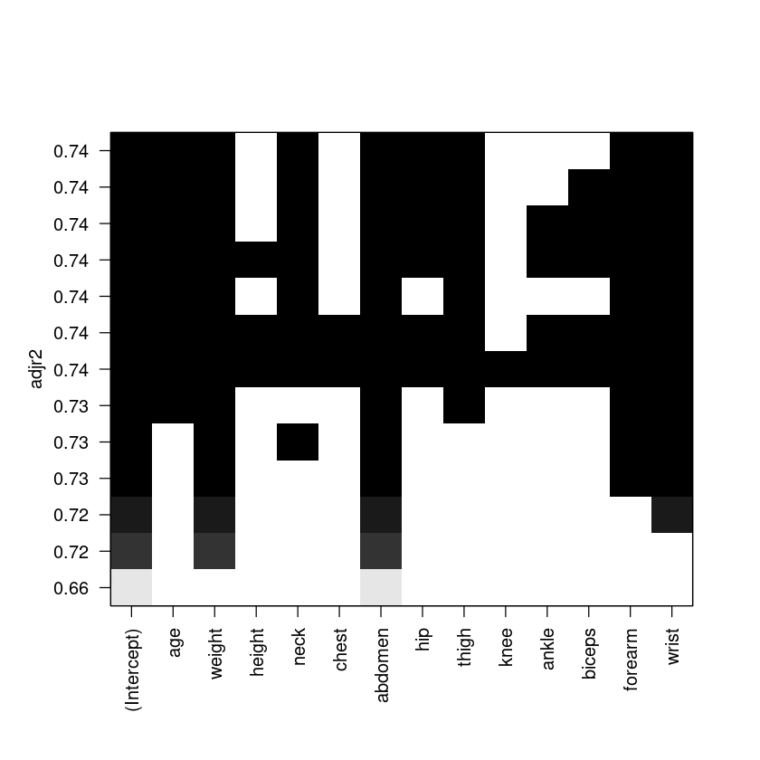

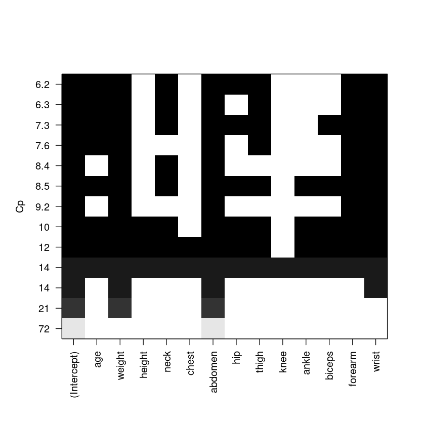

1. 0.662117815140187

2. 0.718726452981407

3. 0.727556313805209

4. 0.735107998874419

5. 0.738004932776657

6. 0.740993454014338

7. 0.744465138137345

8. 0.746668800425452

9. 0.747657608314115

10. 0.748400529629391

11. 0.748909348065416

12. 0.748977071696945

13. 0.748979934086699

1. 0.660766286400748

2. 0.716467227704149

3. 0.724260624052853

4. 0.730818249868336

5. 0.732679829784313

6. 0.734650436561628

7. 0.737134219969155

8. 0.73832867862876

9. 0.738272973912574

10. 0.737960717580818

11. 0.737401026518414

12. 0.736373410024826

13. 0.735268754015805

1. 72.3567001867101

2. 20.6842746091322

3. 14.3124065338894

4. 9.15241699308257

5. 8.40574307191903

6. 7.57223232456087

7. 6.2806196868633

8. 6.19125833377302

9. 7.25373855165728

10. 8.54935154421838

11. 10.0669248213455

12. 12.0027139215303

13. 14

1. -262.375760285935

2. -303.055469508757

3. -305.563765935024

4. -307.117990467025

5. -304.359685378037

6. -301.721286155989

7. -299.592468415869

8. -296.24564261102

9. -291.70175008245

10. -286.915328556617

11. -281.896043925812

12. -276.434592905098

13. -270.908037365177

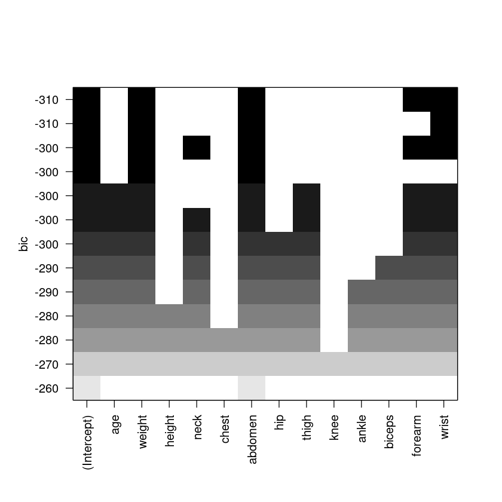

```r
# Plot the selected models
#plot(fit.exhaustive, scale = "aic")
#plot(fit.exhaustive, scale = "r2")
plot(fit.exhaustive, scale = "adjr2")
plot(fit.exhaustive, scale = "Cp")
plot(fit.exhaustive, scale = "bic")


# View model selection criteria
exh_sum$rsq
exh_sum$adjr2
exh_sum$cp
exh_sum$bic
```

```r
#identify the model sizes preferred by adjusted $R^2$, Mallows’ $C_p$, and BIC, respectively.
# Best model size by adjusted R^2
which.max(exh_sum$adjr2)

# Best model size by Mallows' Cp
which.min(exh_sum$cp)

# Best model size by BIC
which.min(exh_sum$bic)

#Adjusted R² prefers model size: 8
#Mallows’ Cp prefers model size: 8
#BIC prefers model size: 4

#The 4‑variable model is the model preferred by BIC
```

8

8

4

```r
exh_sum
```

```
Subset selection object
Call: regsubsets.formula(brozek ~ age + weight + height + neck + chest +
    abdomen + hip + thigh + knee + ankle + biceps + forearm +
    wrist, data = dat, nvmax = 13, method = "exhaustive")
13 Variables  (and intercept)
        Forced in Forced out
age         FALSE      FALSE
weight      FALSE      FALSE
height      FALSE      FALSE
neck        FALSE      FALSE
chest       FALSE      FALSE
abdomen     FALSE      FALSE
hip         FALSE      FALSE
thigh       FALSE      FALSE
knee        FALSE      FALSE
ankle       FALSE      FALSE
biceps      FALSE      FALSE
forearm     FALSE      FALSE
wrist       FALSE      FALSE
1 subsets of each size up to 13
Selection Algorithm: exhaustive
          age weight height neck chest abdomen hip thigh knee ankle biceps
1  ( 1 )  " " " "    " "    " "  " "   "*"     " " " "   " "  " "   " "
2  ( 1 )  " " "*"    " "    " "  " "   "*"     " " " "   " "  " "   " "
3  ( 1 )  " " "*"    " "    " "  " "   "*"     " " " "   " "  " "   " "
4  ( 1 )  " " "*"    " "    " "  " "   "*"     " " " "   " "  " "   " "
5  ( 1 )  " " "*"    " "    "*"  " "   "*"     " " " "   " "  " "   " "
6  ( 1 )  "*" "*"    " "    " "  " "   "*"     " " "*"   " "  " "   " "
7  ( 1 )  "*" "*"    " "    "*"  " "   "*"     " " "*"   " "  " "   " "
8  ( 1 )  "*" "*"    " "    "*"  " "   "*"     "*" "*"   " "  " "   " "
9  ( 1 )  "*" "*"    " "    "*"  " "   "*"     "*" "*"   " "  " "   "*"
10  ( 1 ) "*" "*"    " "    "*"  " "   "*"     "*" "*"   " "  "*"   "*"
11  ( 1 ) "*" "*"    "*"    "*"  " "   "*"     "*" "*"   " "  "*"   "*"
12  ( 1 ) "*" "*"    "*"    "*"  "*"   "*"     "*" "*"   " "  "*"   "*"
13  ( 1 ) "*" "*"    "*"    "*"  "*"   "*"     "*" "*"   "*"  "*"   "*"
          forearm wrist
1  ( 1 )  " "     " "
2  ( 1 )  " "     " "
3  ( 1 )  " "     "*"
4  ( 1 )  "*"     "*"
5  ( 1 )  "*"     "*"
6  ( 1 )  "*"     "*"
7  ( 1 )  "*"     "*"
8  ( 1 )  "*"     "*"
9  ( 1 )  "*"     "*"
10  ( 1 ) "*"     "*"
11  ( 1 ) "*"     "*"
12  ( 1 ) "*"     "*"
13  ( 1 ) "*"     "*"
```

To use Best model size by BIC, the best model is the 4th. The BIC‑optimal model uses weight, abdomen, forearm, and wrist.

### Model diagnosis measures:

normality (QQ normal , normal test)

Residual plots

### Common diagnostic measures in multiple regression

#### 1. Leverage

Leverage measures how unusual the independent values are for observation $i$. Large leverage means the observation is far from the center of the predictor space and may strongly affect the fitted model.

A common rule of thumb is to examine observations with $h_{ii} > \frac{2p}{n}$

where $p$ is the number of parameters in the model, including the intercept, and $n$ is the sample size.

### 2. Studentized residuals

Studentized residuals are used to detect **outliers** in the response variable. Large absolute values suggest that the observed response is unusual relative to the fitted model.

A common guideline is to check observations with

$$ |t_i| > 3. $$

### 3. Cook’s distance

Cook’s distance measures the overall influence of an observation on the fitted regression model. It combines information from both the residual size and the leverage.

Large values of $D_i$ suggest that removing observation $i$ may noticeably change the fitted model.

Common rough guidelines are to examine observations with $D_i > \frac{4}{n}$.

### 4. Variance inflation factor (VIF)

VIF measures how strongly predictor $X_j$ is linearly related to the other predictors. Large VIF values indicate multicollinearity, which inflates the variance of the estimated coefficient $\hat{\beta}_j$.

A common interpretation is:

- $\mathrm{VIF} > 5$: potentially problematic
- $\mathrm{VIF} > 10$: serious multicollinearity

```r
#
fit.1 = lm(brozek ~  weight + abdomen + forearm + wrist, data = dat)
```

```r
## VIF
library(car)
vif(fit.1)

#No VIF is above 10, no serious  multicollinearity issue.
```

**weight**

7.04077399069224

**abdomen**

4.8643799985043

**forearm**

1.79337411013762

**wrist**

2.27304746118134

```r
length(dat$weight)

2*4/252
```

252

0.0317460317460317

1. 9

2. 12

3. 36

4. 39

5. 41

6. 45

7. 81

8. 96

9. 113

10. 152

11. 159

12. 166

13. 175

14. 178

15. 205

16. 206

17. 216

18. 221

19. 226

20. 242

21. 248

22. 249

23. 250

24. 252

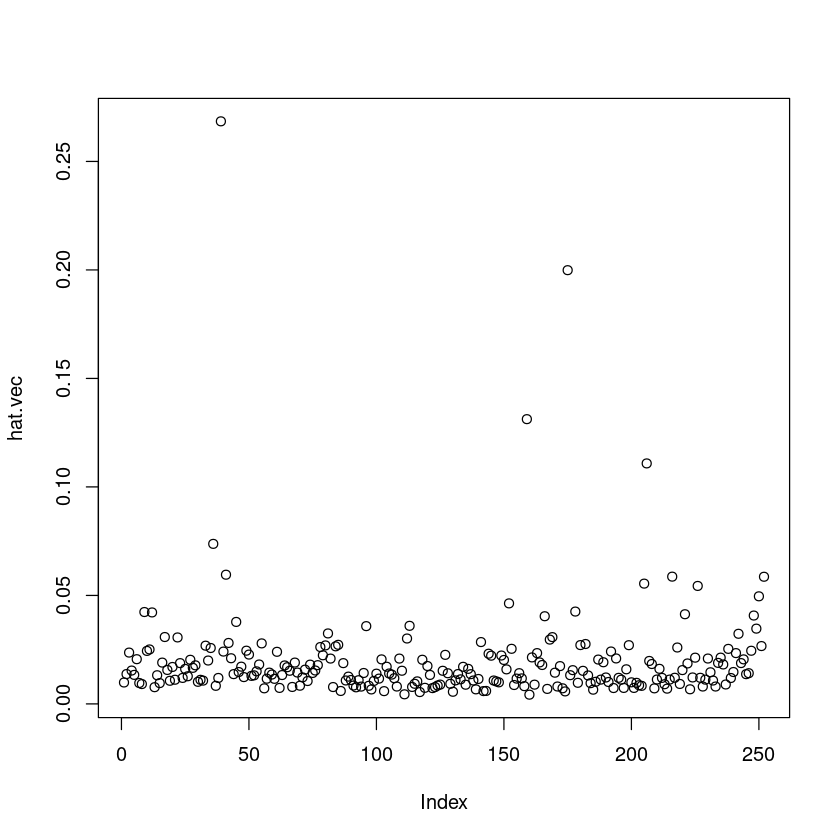

```r
# leverage
hat.vec = hatvalues(fit.1) # \frac{2p}{n}$

#p = the number of variables = 4,     n = 252
#Cut off   2*4/252

plot(hat.vec)

#sum(hatvalues(fit.1)>0.0317460317460317)

(1:length(dat$weight))[hat.vec>0.0317460317460317]
```

0

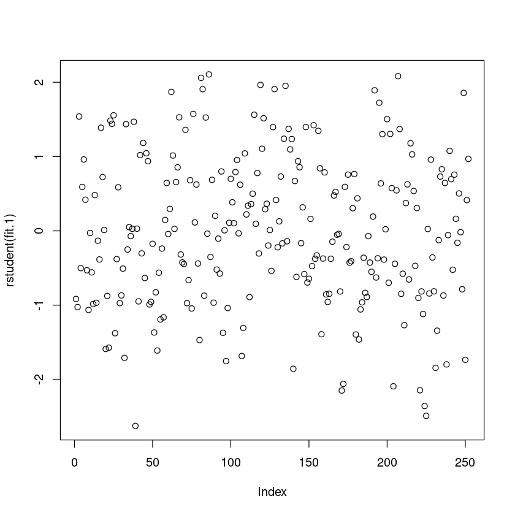

```r
# studentized residuals
rstudent(fit.1)

plot(rstudent(fit.1) )

sum(rstudent(fit.1) >3)

#no outliers in y (response) direction
```

10

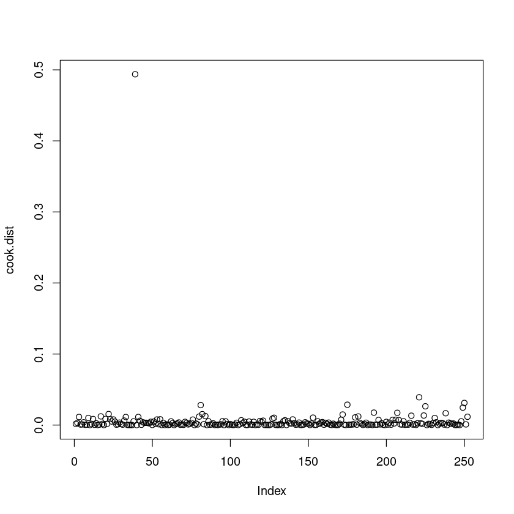

```r
# Cook's distance
cook.dist = cooks.distance(fit.1)
plot(cook.dist)

#D_i > \frac{4}{n}
sum(cook.dist> 4/252)
```

```r
(1:length(dat$weight))[cook.dist> 4/252]
```

1. 39

2. 81

3. 175

4. 192

5. 207

6. 221

7. 225

8. 238

9. 249

10. 250

```r
dat[39,]
```

A data.frame: 1 × 14

|  | brozek <dbl> | age <int> | weight <dbl> | height <dbl> | neck <dbl> | chest <dbl> | abdomen <dbl> | hip <dbl> | thigh <dbl> | knee <dbl> | ankle <dbl> | biceps <dbl> | forearm <dbl> | wrist <dbl> |
| --- | --- | --- | --- | --- | --- | --- | --- | --- | --- | --- | --- | --- | --- | --- |
| 39 | 33.8 | 46 | 363.15 | 72.25 | 51.2 | 136.2 | 148.1 | 147.7 | 87.3 | 49.1 | 29.6 | 45 | 29 | 21.4 |

## ANCOVA (Analysis of Covariance)

**ANCOVA** stands for **analysis of covariance**. It is a statistical method that extends ANOVA by incorporating one or more **continuous covariates** into the model. The main purpose of ANCOVA is to compare the means of different groups **after adjusting for the effect of other continuous variables** that may influence the response.

In other words, ANCOVA helps remove variation in the response variable that is explained by a covariate, so that the comparison among groups becomes more precise.

- **ANOVA** compares group means.
- **Regression** studies the relationship between a response and continuous predictors.
- **ANCOVA** does both at the same time: it compares group means while controlling for continuous covariates.

### Example

Suppose we want to compare students' final exam scores across three teaching methods, while adjusting for students' pre-test scores.

- **Response variable**: final exam score
- **Factor**: teaching method
- **Covariate**: pre-test score

ANCOVA adjusts the final exam scores for differences in pre-test scores, then compares the adjusted group means.

A common ANCOVA model with one factor and one covariate is $Y_{ij} = \mu + \tau_i + \beta X_{ij} + \varepsilon_{ij},$

where:

- $Y_{ij}$: response for subject $j$ in group $i$
- $\mu$: overall mean
- $\tau_i$: effect of group $i$
- $X_{ij}$: covariate value
- $\beta$: regression coefficient for the covariate
- $\varepsilon_{ij}$: random error

Sometimes the model is written with centered covariates:

$Y_{ij} = \mu + \tau_i + \beta (X_{ij} - \bar{X}) + \varepsilon_{ij}.$

This form can make interpretation of adjusted means easier.

The covariate explains part of the variability in the response. After accounting for that effect, ANCOVA tests whether the adjusted group means are significantly different.

- If the **group effect** is significant, then the groups differ after controlling for the covariate.
- If the **covariate effect** is significant, then the covariate is associated with the response.
- The adjusted group means are often called **least squares means** or **estimated marginal means**.

### Assumptions of ANCOVA

ANCOVA relies on several assumptions:

1. **Linearity**  
   The relationship between the response and the covariate is linear.
2. **Independence**  
   Observations are independent.
3. **Normality**  
   The errors are approximately normally distributed.
4. **Equal variance**  
   The error variance is the same across groups.
5. **Homogeneity of regression slopes**  
   The relationship between the response and the covariate is the same across groups.

The last assumption is especially important. It means that the slope for the covariate does not depend on the group. If this assumption fails, an interaction term may be needed:

$Y_{ij} = \mu + \tau_i + \beta X_{ij} + \gamma_i X_{ij} + \varepsilon_{ij}.$

If the interaction between group and covariate is significant, the standard ANCOVA model may not be appropriate.

## Regression with Both Quantitative and Categorical Independent Variables

#### Example:

This dataset contains information on **36 students** who were taught using one of **four teaching methods**: **A, B, C,** and **D**. There are **9 students in each teaching-method group**. For each student, the dataset records the amount of **study time** and the resulting **score**.

The variables are defined as follows:

- **Student**: student identification number
- **Method**: teaching method used for the student, with four levels: A, B, C, and D
- **Time**: time spent studying, measured in hours
- **Score**: performance score of the student

This dataset is suitable for studying how **Score** is related to **Time** and whether the teaching methods differ in their effects. In particular, the data suggest a positive relationship between study time and score, while also allowing comparisons among the four teaching methods. Because the slopes may vary somewhat across methods, the dataset can also be used to illustrate regression models with interaction terms.

## Data table

| Student | Method | Time | Score |
| --- | --- | --- | --- |
| 1 | A | 4.7 | 75.3 |
| 2 | A | 2.3 | 59.2 |
| 3 | A | 3.6 | 64.7 |
| 4 | A | 2.4 | 65.7 |
| 5 | A | 1.9 | 59.0 |
| 6 | A | 3.8 | 63.7 |
| 7 | A | 3.5 | 67.3 |
| 8 | A | 3.2 | 65.0 |
| 9 | A | 1.9 | 60.0 |
| 10 | B | 2.7 | 66.8 |
| 11 | B | 2.4 | 62.7 |
| 12 | B | 3.4 | 70.9 |
| 13 | B | 2.6 | 64.2 |
| 14 | B | 6.1 | 82.2 |
| 15 | B | 4.3 | 76.6 |
| 16 | B | 3.7 | 71.5 |
| 17 | B | 3.9 | 69.8 |
| 18 | B | 5.6 | 82.8 |
| 19 | C | 3.7 | 81.0 |
| 20 | C | 2.2 | 71.9 |
| 21 | C | 1.8 | 68.8 |
| 22 | C | 5.5 | 84.3 |
| 23 | C | 6.4 | 95.8 |
| 24 | C | 3.2 | 72.9 |
| 25 | C | 5.0 | 91.7 |
| 26 | C | 1.6 | 72.4 |
| 27 | C | 3.3 | 74.7 |
| 28 | D | 2.6 | 58.3 |
| 29 | D | 2.7 | 59.8 |
| 30 | D | 4.4 | 70.0 |
| 31 | D | 5.9 | 74.2 |
| 32 | D | 5.9 | 73.9 |
| 33 | D | 5.8 | 71.4 |
| 34 | D | 3.6 | 65.7 |
| 35 | D | 3.4 | 62.4 |
| 36 | D | 1.2 | 50.5 |

```r
#Response : Score
#Independent variables:  Method, Time

loc = "TimeScore.csv"
dat = read.csv(loc, header = 1)

dat$Method = factor(dat$Method)
```

**Model 1: ANCOVA (assuming equal slopes across all groups)**

$Score_i = \beta_0 + \beta_1 \, Time_i + \text{(effect of teaching method)} + e_i$

Equivalently,

$Score_i = \beta_0 + \beta_1 \, Time_i + \tau_{j(i)} + e_i$

where $\tau_{j(i)}$ represents the effect of the $j$-th level of the categorical variable (teaching method) for student $i$.

**Dummy Variables**

Dummy variables are used to indicate group membership for the categorical variable.

Since *Method* has 4 groups, we need 3 dummy variables.

For example:

```r
#Regression
fit = lm(Score ~ Method + Time, data = dat)

summary(fit)
```

```
Call:
lm(formula = Score ~ Method + Time, data = dat)

Residuals:
    Min      1Q  Median      3Q     Max
-4.5777 -1.4754 -0.0475  1.5680  5.5692

Coefficients:
            Estimate Std. Error t value Pr(>|t|)
(Intercept)  49.2229     1.2844  38.325  < 2e-16 ***
MethodB       3.3881     1.2393   2.734  0.01025 *
MethodC      11.8358     1.2266   9.649 7.46e-11 ***
MethodD      -3.8687     1.2455  -3.106  0.00403 **
Time          5.0144     0.3154  15.899  < 2e-16 ***
---
Signif. codes:  0 ‘***’ 0.001 ‘**’ 0.01 ‘*’ 0.05 ‘.’ 0.1 ‘ ’ 1

Residual standard error: 2.571 on 31 degrees of freedom
Multiple R-squared:  0.9355,	Adjusted R-squared:  0.9271
F-statistic: 112.3 on 4 and 31 DF,  p-value: < 2.2e-16
```

Method A is the baseline (the reference). The estimated difference between method B and method A is 3.38.

The fitted model:

For Teaching method "A":

$ \hat {Score} = 49.2229 + 5.0144 \times Time $

For Teaching method "B":

$ \hat {Score} = 49.2229 + 3.3881 + 5.0144 \times Time = 52.611 + 5.0144 \times Time $

For Teaching method "C":

$ \hat {Score} = 49.2229 + 11.8358 + 5.0144 \times Time = 61.0587 + 5.0144 \times Time $

For Teaching method "D":

$ \hat {Score} = 49.2229 -3.8687 + 5.0144 \times Time = 45.3542 + 5.0144 \times Time $

```r
#ANOVA analysis for the model
summary(aov(fit))
```

```
            Df Sum Sq Mean Sq F value   Pr(>F)
Method       3 1299.4   433.1   65.53 1.61e-13 ***
Time         1 1670.7  1670.7  252.79  < 2e-16 ***
Residuals   31  204.9     6.6
---
Signif. codes:  0 ‘***’ 0.001 ‘**’ 0.01 ‘*’ 0.05 ‘.’ 0.1 ‘ ’ 1
```

These results indicate that time (p-value ≈ 0.000000) is a significant predictor of Score. The effect of Method is also significant (p-value = 1.61e-13), suggesting that the average scores differ across teaching methods when students have the same study time.

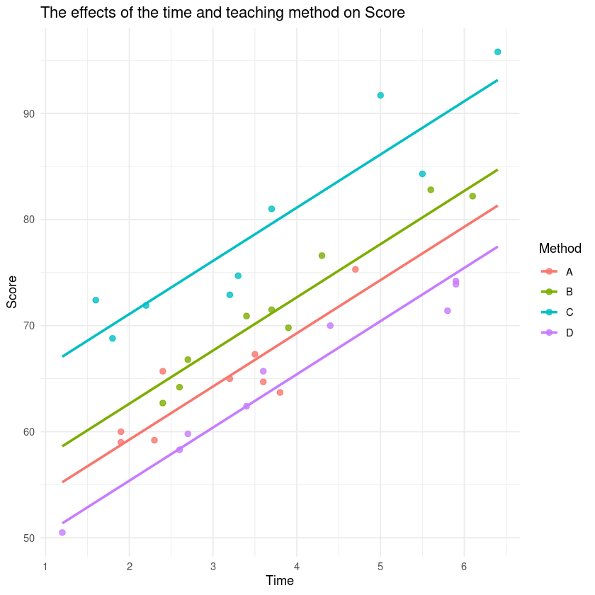

```r
#Visulize the fitted model

library(ggplot2)

# Create prediction grid
xgrid <- seq(min(dat$Time), max(dat$Time), length.out = 100)
newdat <- expand.grid(
  Time = xgrid,
  Method = levels(dat$Method)
)

# Predicted values from common-slope ANCOVA model
newdat$yhat <- predict(fit, newdata = newdat)

# Plot
ggplot(dat, aes(x = Time, y = Score, color = Method)) +
  geom_point(size = 2, alpha = 0.8) +
  geom_line(data = newdat, aes(x = Time, y = yhat, color = Method), linewidth = 1) +
  labs(
    title = "The effects of the time and teaching method on Score",
    x = "Time",
    y = "Score"
  ) +
  theme_minimal()
```

### A slightly more complicated model with interactions between covariates (continuous independent variables) and factors (categorical variables)

$Y_{ij} = \mu + \tau_i + \beta X_{ij} + \gamma_i X_{ij} + \varepsilon_{ij}$

Regression model with interaction between a factor and a continuous independent variable At different levels of the teaching method, the slope for "Time" may differ. This is modeled by the interaction between Time and Method.

```r
#Regression model with interaction between a factor and a continuous independent variable
#At different level of teaching method, the slope for "Time" may be different ,  which is modelled by the interaction
#between Time and Method.
fit.2 = lm(Score ~ Method * Time, data = dat)
summary(fit.2)
```

```
Call:
lm(formula = Score ~ Method * Time, data = dat)

Residuals:
    Min      1Q  Median      3Q     Max
-4.7959 -1.8077 -0.1421  1.3891  5.2340

Coefficients:
             Estimate Std. Error t value Pr(>|t|)
(Intercept)   50.8363     3.0765  16.524 5.67e-16 ***
MethodB        0.1544     4.2372   0.036    0.971
MethodC        9.3312     3.7816   2.468    0.020 *
MethodD       -4.2011     3.8832  -1.082    0.289
Time           4.4825     0.9715   4.614 7.97e-05 ***
MethodB:Time   0.9522     1.2093   0.787    0.438
MethodC:Time   0.7772     1.1185   0.695    0.493
MethodD:Time   0.2071     1.1201   0.185    0.855
---
Signif. codes:  0 ‘***’ 0.001 ‘**’ 0.01 ‘*’ 0.05 ‘.’ 0.1 ‘ ’ 1

Residual standard error: 2.65 on 28 degrees of freedom
Multiple R-squared:  0.9381,	Adjusted R-squared:  0.9226
F-statistic: 60.59 on 7 and 28 DF,  p-value: 3.11e-15
```

```r
step(fit.2)
```

```
Start:  AIC=77.12
Score ~ Method * Time

              Df Sum of Sq    RSS    AIC
- Method:Time  3    8.2559 204.88 72.601
<none>                     196.63 77.121

Step:  AIC=72.6
Score ~ Method + Time

         Df Sum of Sq     RSS     AIC
<none>                 204.88  72.601
- Method  3    1208.6 1413.48 136.130
- Time    1    1670.7 1875.60 150.314
```

```
Call:
lm(formula = Score ~ Method + Time, data = dat)

Coefficients:
(Intercept)      MethodB      MethodC      MethodD         Time
     49.223        3.388       11.836       -3.869        5.014
```

```r
#Is the model with interactions better than the model with interation
anova(fit, fit.2)

#p-value = 0.759, fail to reject H0.
#There is no evidence in the data to support that the model with interaction is better than the simple model without interaction.
```

A anova: 2 × 6

|  | Res.Df <dbl> | RSS <dbl> | Df <dbl> | Sum of Sq <dbl> | F <dbl> | Pr(>F) <dbl> |
| --- | --- | --- | --- | --- | --- | --- |
| 1 | 31 | 204.8839 | NA | NA | NA | NA |
| 2 | 28 | 196.6280 | 3 | 8.255925 | 0.3918836 | 0.7597675 |

It is not necessary to use the model with interactions for this data.

Example: Regresssion analysis for the diamond data to see how price depends on Weight, and color.

```r
loc = "diamond.csv"

dat = read.csv(loc, header = 1)

head(dat)
```

A data.frame: 6 × 5

|  | Weight <dbl> | Color <chr> | Clarity <chr> | Certificate <chr> | Price <int> |
| --- | --- | --- | --- | --- | --- |
| 1 | 0.30 | D | VS2 | GIA | 1302 |
| 2 | 0.30 | E | VS1 | GIA | 1510 |
| 3 | 0.30 | G | VVS1 | GIA | 1510 |
| 4 | 0.30 | G | VS1 | GIA | 1260 |
| 5 | 0.31 | D | VS1 | GIA | 1641 |
| 6 | 0.31 | E | VS1 | GIA | 1555 |

```r
#Regression analysis

#Model without interaction
fit.wo = lm(Price ~ Weight + Color, data = dat)

#Model with interaction between Weight and Color
fit.wi = lm(Price ~ Weight * Color, data = dat)


summary(fit.wo)

summary(fit.wi)

#To compare both models
anova(fit.wo, fit.wi)
```

```
Call:
lm(formula = Price ~ Weight + Color, data = dat)

Residuals:
    Min      1Q  Median      3Q     Max
-703.41 -198.37  -57.42  146.02 1541.10

Coefficients:
            Estimate Std. Error t value Pr(>|t|)
(Intercept)  -1731.3      204.4  -8.470 7.51e-13 ***
Weight       10409.0      242.8  42.862  < 2e-16 ***
ColorE         144.5      199.5   0.724  0.47100
ColorF        -180.0      192.6  -0.934  0.35286
ColorG        -363.7      197.1  -1.846  0.06853 .
ColorH        -638.0      200.2  -3.187  0.00203 **
ColorI       -1152.8      222.8  -5.173 1.57e-06 ***
---
Signif. codes:  0 ‘***’ 0.001 ‘**’ 0.01 ‘*’ 0.05 ‘.’ 0.1 ‘ ’ 1

Residual standard error: 355.7 on 83 degrees of freedom
Multiple R-squared:  0.9584,	Adjusted R-squared:  0.9554
F-statistic: 318.9 on 6 and 83 DF,  p-value: < 2.2e-16
```

```
Call:
lm(formula = Price ~ Weight * Color, data = dat)

Residuals:
    Min      1Q  Median      3Q     Max
-606.65 -179.98  -47.41  196.38 1209.48

Coefficients:
              Estimate Std. Error t value Pr(>|t|)
(Intercept)   -1649.89     640.12  -2.577   0.0118 *
Weight        10212.99    1490.88   6.850 1.52e-09 ***
ColorE        -1015.70     725.18  -1.401   0.1653
ColorF         -550.32     684.85  -0.804   0.4241
ColorG         -170.17     703.76  -0.242   0.8096
ColorH         -603.12     682.30  -0.884   0.3794
ColorI         -428.04     729.06  -0.587   0.5588
Weight:ColorE  2434.80    1641.28   1.483   0.1420
Weight:ColorF   740.59    1555.30   0.476   0.6353
Weight:ColorG  -388.74    1607.10  -0.242   0.8095
Weight:ColorH   -16.96    1545.52  -0.011   0.9913
Weight:ColorI -1128.09    1585.86  -0.711   0.4790
---
Signif. codes:  0 ‘***’ 0.001 ‘**’ 0.01 ‘*’ 0.05 ‘.’ 0.1 ‘ ’ 1

Residual standard error: 328.3 on 78 degrees of freedom
Multiple R-squared:  0.9667,	Adjusted R-squared:  0.962
F-statistic: 205.9 on 11 and 78 DF,  p-value: < 2.2e-16
```

A anova: 2 × 6

|  | Res.Df <dbl> | RSS <dbl> | Df <dbl> | Sum of Sq <dbl> | F <dbl> | Pr(>F) <dbl> |
| --- | --- | --- | --- | --- | --- | --- |
| 1 | 83 | 10498952 | NA | NA | NA | NA |
| 2 | 78 | 8408550 | 5 | 2090401 | 3.878226 | 0.003429505 |

Since p-value to comare the model with interaction, the model without interaction is 0.0034, which is below 0.01, reject H0. There is sufficient evidence that the model with the interaction between Weight and Color is better. We should use " fit.wi = lm(Price ~ Weight * Color, data = dat) "

```r
#Find the baseline
table(dat$Color)
```

```
 D  E  F  G  H  I
 4 16 27 18 17  8
```

```r
#ANOVA analysis
s.fit = aov(fit.wi)
```

```r
summary(s.fit)
```

```
             Df    Sum Sq   Mean Sq  F value   Pr(>F)
Weight        1 230867858 230867858 2141.593  < 2e-16 ***
Color         5  11199026   2239805   20.777 3.89e-13 ***
Weight:Color  5   2090401    418080    3.878  0.00343 **
Residuals    78   8408550    107802
---
Signif. codes:  0 ‘***’ 0.001 ‘**’ 0.01 ‘*’ 0.05 ‘.’ 0.1 ‘ ’ 1
```

According to the ANOVA analysis for the the regression, we can also tell the interaction between Weight and Color is signficant. If the interaction term is significant, the effects of a factor is significant, and the p-value of the main effects may not be meaningful.

If the interaction term is significant, the slope for different level is different.

Color "D" is the baseline (the reference). However, the sample size of color 'D' is 4. We need to be careful. In practice, we may need to combine two or more similar colors into one according to the features.

Anyway, let list the results based on the output:

The fitted model for Color 'D': $ \hat {Price} = -1649.89 + 10212.99 \times Weight $

The fitted model for Color "E": $ \hat {Price} = -1649.89 -1015.70 + ( 10212.99 + 2434.80 ) \times Weight $

which is the same as $ \hat {Price} = -2665.59 + 12647.79 \times Weight $

The fitted model for Color "F":

$ \hat {Price} = -2200.21 + 10953.58 \times Weight $

...

```r
-1649.89 -1015.70
10212.99 + 2434.80
```

-2665.59

12647.79

```r
-1649.89 -550.32

10212.99 +   740.59
```

-2200.21

10953.58

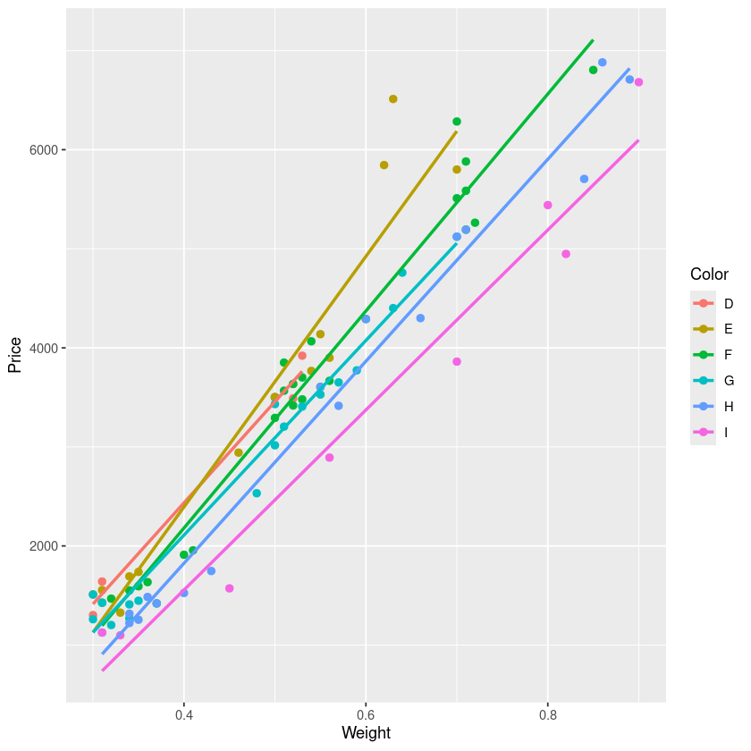

```r
ggplot(dat, aes(x = Weight, y = Price, color = Color)) +
  geom_point(size = 2) +
  geom_smooth(method = "lm", se = FALSE)
  labs(
    title = "ANCOVA Plot with different slope",
    x = "Weight",
    y = "Price"
  ) +
  theme_minimal()
```

In the model with interaction, the slope for different groups may be different.

```r
#Using mtcars data
data(mtcars)
head(mtcars)
```

A data.frame: 6 × 11

|  | mpg <dbl> | cyl <dbl> | disp <dbl> | hp <dbl> | drat <dbl> | wt <dbl> | qsec <dbl> | vs <dbl> | am <dbl> | gear <dbl> | carb <dbl> |
| --- | --- | --- | --- | --- | --- | --- | --- | --- | --- | --- | --- |
| Mazda RX4 | 21.0 | 6 | 160 | 110 | 3.90 | 2.620 | 16.46 | 0 | 1 | 4 | 4 |
| Mazda RX4 Wag | 21.0 | 6 | 160 | 110 | 3.90 | 2.875 | 17.02 | 0 | 1 | 4 | 4 |
| Datsun 710 | 22.8 | 4 | 108 | 93 | 3.85 | 2.320 | 18.61 | 1 | 1 | 4 | 1 |
| Hornet 4 Drive | 21.4 | 6 | 258 | 110 | 3.08 | 3.215 | 19.44 | 1 | 0 | 3 | 1 |
| Hornet Sportabout | 18.7 | 8 | 360 | 175 | 3.15 | 3.440 | 17.02 | 0 | 0 | 3 | 2 |
| Valiant | 18.1 | 6 | 225 | 105 | 2.76 | 3.460 | 20.22 | 1 | 0 | 3 | 1 |

```r
#To predict mpg using disp, hp, and wt and with am (manual vs auto transmission), cyl (can be converted to a factor ).

#For illustratrtion purpose
dat = mtcars
dat$cyl = factor(mtcars$cyl)
#dat$am = factor(mtcars$am)

#This model allows interactions between disp and cyl
fit2 = lm( mpg ~ disp + disp*cyl , data =dat )

fit1 = lm( mpg ~ disp + cyl , data =dat )

#Tell if fit2 is significant better or not
anova(fit1, fit2)
```

A anova: 2 × 6

|  | Res.Df <dbl> | RSS <dbl> | Df <dbl> | Sum of Sq <dbl> | F <dbl> | Pr(>F) <dbl> |
| --- | --- | --- | --- | --- | --- | --- |
| 1 | 28 | 243.6198 | NA | NA | NA | NA |
| 2 | 26 | 146.2343 | 2 | 97.38552 | 8.657422 | 0.001313336 |